# DTF via Robust Scaling: Replication Code for Simulation 1

Author

Peter F Halpin

Published

August 6, 2026

# Initialization

```r
library(robustDIF)
library(dplyr)
library(tidyr)
library(ggplot2)
library(see)

check_archive_robustDIF <- function(version = "0.2.0.20260708",
                                    archive.name = "Halpin2024-JEBS-archive") {
  installed_version <- as.character(utils::packageVersion("robustDIF"))
  if (installed_version != version) {
    stop(
      "This report expects robustDIF ", version,
      ", but found robustDIF ", installed_version,
      ". Install robustDIF from the Halpin2024-archive branch.",
      call. = FALSE)
  }

  desc <- utils::packageDescription("robustDIF")
  installed_archive <- desc[["Config/robustDIF/archive-name"]]
  if (!identical(installed_archive, archive.name)) {
    stop(
      "This report expects robustDIF archive '", archive.name,
      "', but found archive label '", installed_archive,
      "'. Install robustDIF from the Halpin2024-archive branch.",
      call. = FALSE)
  }
  invisible(installed_version)
}

check_archive_robustDIF()

find_results_dir <- function(candidates, pattern, min_files) {
  candidates <- unique(candidates)
  n_files <- vapply(
    candidates,
    function(path) {
      if (!dir.exists(path)) return(0L)
      length(list.files(path, pattern = pattern, full.names = TRUE))
    },
    integer(1))

  if (!any(n_files >= min_files)) {
    stop(
      "Could not find the Simulation 1 result files. Expected at least ",
      min_files, " files matching ", pattern, " in one of: ",
      paste(candidates, collapse = ", "),
      call. = FALSE)
  }

  normalizePath(candidates[which(n_files >= min_files)[1]], mustWork = TRUE)
}

sim1_pattern <- "^sim1_n[0-9]+_ndif[0-9]+[.]rds$"
results_dir <- find_results_dir(
  c(
    "../results/sim1",
    "results/sim1",
    "../../paper/results/sim1",
    "../../../paper/results/sim1",
    "paper/results/sim1"),
  pattern = sim1_pattern,
  min_files = 33L)

method_levels <- c("LRT", "RDIF", "True")

method_cols <- c(
  "LRT" = "#254A73",
  "RDIF" = "#7BAFD4",
  "True" = "grey50")

delta_method_map <- c(
  "LRT-unit" = "LRT",
  "RDIF-BH-start" = "RDIF",
  "Oracle-unit" = "True")

item_method_map <- c(
  "LRT" = "LRT",
  "RDIF-BH-start" = "RDIF")

theme_set(theme_bw(base_size = 14))
```

# Run Sims

The production run was carried out condition-by-condition. Each condition was saved separately as an `.rds`.

```bash
SIM1_REPS=500 SIM1_CORES=10 SIM1_LRT_TOL=1e-3 \
  Rscript run_sim1.R
```

Simulation 1 uses 500 replications in each cell of a `3 x 11` grid:

- sample size per group: `200`, `350`, `500`;
- number of DIF items: `0, 1, ..., 10`;
- total number of items: `20`;
- per-item DIF magnitude: `0.5` on the difficulty scale used in `data_sim1()`;
- reference latent mean and variance fixed at `0` and `1`;
- comparison latent mean sampled from `U(-0.25, 0.25)`;
- comparison latent variance sampled from `U(0.5, 1.5)`.

The LRT screening step uses joint slope/intercept item tests with `TOL = 1e-3`; this was done to improve run time and piloting showed it had a neglible effect on convergence. The separate single-group `mirt(..., SE = TRUE)` fits used by RDIF are left at the `mirt` defaults.

# Load Results

```r
sim_files <- list.files(
  results_dir,
  pattern = sim1_pattern,
  full.names = TRUE)

sim_list <- lapply(sim_files, readRDS)
sim_delta_all <- bind_rows(lapply(sim_list, `[[`, "delta")) |>
  mutate(
    raw_method = as.character(method),
    n_persons = n_persons_1,
    n_dif = as.integer(n_dif))

sim_delta <- sim_delta_all |>
  filter(raw_method %in% names(delta_method_map)) |>
  mutate(
    method = factor(unname(delta_method_map[raw_method]), levels = method_levels))

sim_items_all <- bind_rows(lapply(sim_list, `[[`, "items")) |>
  mutate(
    raw_method = as.character(method),
    n_persons = n_persons_1,
    n_dif = as.integer(n_dif))

sim_items <- sim_items_all |>
  filter(raw_method %in% names(item_method_map)) |>
  mutate(
    method = factor(unname(item_method_map[raw_method]),
                    levels = c("LRT", "RDIF")))

run_info <- bind_rows(lapply(sim_list, function(x) {
  data.frame(
    n.reps = x$run$n.reps,
    n.cores = x$run$n.cores,
    base.seed = x$run$base.seed,
    condition.seed = x$run$condition.seed,
    lrt.TOL = x$run$lrt.TOL,
    save.mle = x$run$save.mle,
    completed = x$run$completed)
}))

status_file <- file.path(results_dir, "sim1_status.csv")
sim_status <- if (file.exists(status_file)) read.csv(status_file) else NULL

n_reps <- length(unique(sim_delta$rep))
n_items <- unique(sim_delta$n_items)
alpha <- 0.05
```

# Item-Level Diagnostics

```r
item_diag <- sim_items |>
  summarize(
    flagged_rate = mean(flagged, na.rm = TRUE),
    mean_p = mean(p_value, na.rm = TRUE),
    mean_p_adjusted = mean(p_adjusted, na.rm = TRUE),
    .by = c(method, n_persons, n_dif, true_dif)) |>
  mutate(
    diagnostic = ifelse(true_dif, "True positive rate", "False positive rate"))

knitr::kable(item_diag, digits = 3)
```

| method | n_persons | n_dif | true_dif | flagged_rate | mean_p | mean_p_adjusted | diagnostic |
| --- | --- | --- | --- | --- | --- | --- | --- |
| LRT | 200 | 0 | FALSE | 0.003 | 0.495 | 0.798 | False positive rate |
| RDIF | 200 | 0 | FALSE | 0.003 | 0.506 | 0.815 | False positive rate |
| LRT | 200 | 1 | FALSE | 0.002 | 0.498 | 0.780 | False positive rate |
| LRT | 200 | 1 | TRUE | 0.200 | 0.142 | 0.417 | True positive rate |
| RDIF | 200 | 1 | FALSE | 0.004 | 0.505 | 0.792 | False positive rate |
| RDIF | 200 | 1 | TRUE | 0.250 | 0.151 | 0.399 | True positive rate |
| LRT | 200 | 2 | FALSE | 0.004 | 0.496 | 0.757 | False positive rate |
| LRT | 200 | 2 | TRUE | 0.201 | 0.162 | 0.408 | True positive rate |
| RDIF | 200 | 2 | FALSE | 0.007 | 0.506 | 0.771 | False positive rate |
| RDIF | 200 | 2 | TRUE | 0.225 | 0.161 | 0.410 | True positive rate |
| LRT | 200 | 3 | TRUE | 0.216 | 0.163 | 0.385 | True positive rate |
| LRT | 200 | 3 | FALSE | 0.005 | 0.493 | 0.733 | False positive rate |
| RDIF | 200 | 3 | TRUE | 0.243 | 0.158 | 0.369 | True positive rate |
| RDIF | 200 | 3 | FALSE | 0.006 | 0.502 | 0.748 | False positive rate |
| LRT | 200 | 4 | FALSE | 0.006 | 0.492 | 0.719 | False positive rate |
| LRT | 200 | 4 | TRUE | 0.187 | 0.177 | 0.387 | True positive rate |
| RDIF | 200 | 4 | FALSE | 0.009 | 0.508 | 0.741 | False positive rate |
| RDIF | 200 | 4 | TRUE | 0.248 | 0.178 | 0.376 | True positive rate |
| LRT | 200 | 5 | FALSE | 0.008 | 0.473 | 0.679 | False positive rate |
| LRT | 200 | 5 | TRUE | 0.146 | 0.204 | 0.405 | True positive rate |
| RDIF | 200 | 5 | FALSE | 0.013 | 0.502 | 0.720 | False positive rate |
| RDIF | 200 | 5 | TRUE | 0.238 | 0.203 | 0.392 | True positive rate |
| LRT | 200 | 6 | FALSE | 0.009 | 0.465 | 0.656 | False positive rate |
| LRT | 200 | 6 | TRUE | 0.140 | 0.212 | 0.398 | True positive rate |
| RDIF | 200 | 6 | FALSE | 0.021 | 0.492 | 0.691 | False positive rate |
| RDIF | 200 | 6 | TRUE | 0.240 | 0.209 | 0.377 | True positive rate |
| LRT | 200 | 7 | FALSE | 0.014 | 0.440 | 0.621 | False positive rate |
| LRT | 200 | 7 | TRUE | 0.106 | 0.248 | 0.432 | True positive rate |
| RDIF | 200 | 7 | FALSE | 0.024 | 0.483 | 0.673 | False positive rate |
| RDIF | 200 | 7 | TRUE | 0.219 | 0.236 | 0.399 | True positive rate |

[output cut: 96 more lines]

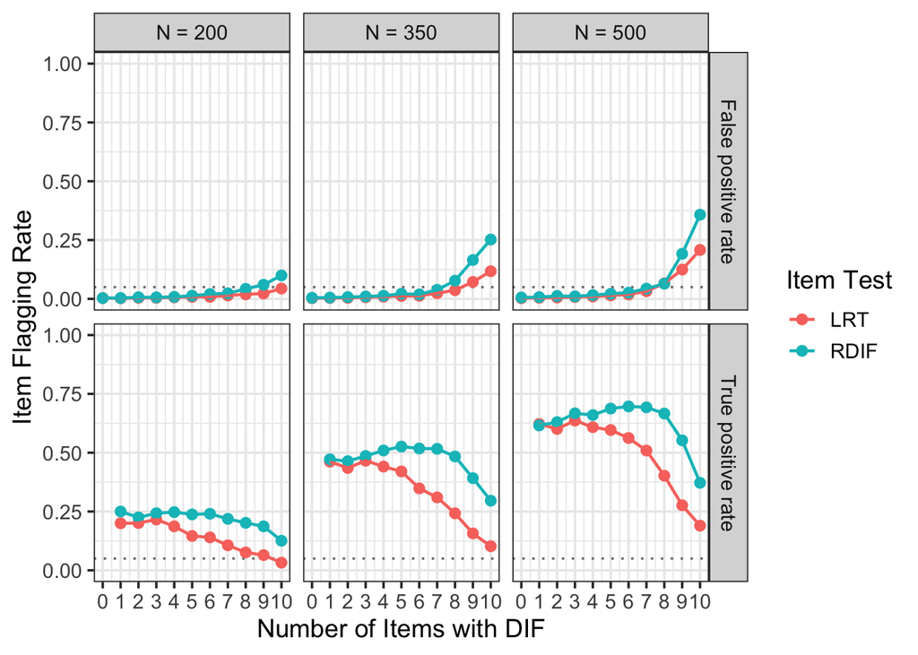

```r
ggplot(
  item_diag,
  aes(x = n_dif, y = flagged_rate, color = method, group = method)) +
  geom_hline(yintercept = alpha, linetype = 3, color = "grey50") +
  geom_point(size = 2.2) +
  geom_line(linewidth = 0.8) +
  scale_x_continuous(breaks = 0:10) +
  scale_y_continuous(limits = c(0, 1), breaks = seq(0, 1, 0.25)) +
  facet_grid(
    diagnostic ~ n_persons,
    labeller = labeller(n_persons = function(x) paste0("N = ", x))) +
  labs(
    x = "Number of Items with DIF",
    y = "Item Flagging Rate",
    color = "Item Test")
```

# Bias and Precision

## Scaling Function Bias

Figure 2 from the paper. `Naive` is the mean of all item-level scaling functions. The other methods use the method-specific estimate of the common-item scaling function.

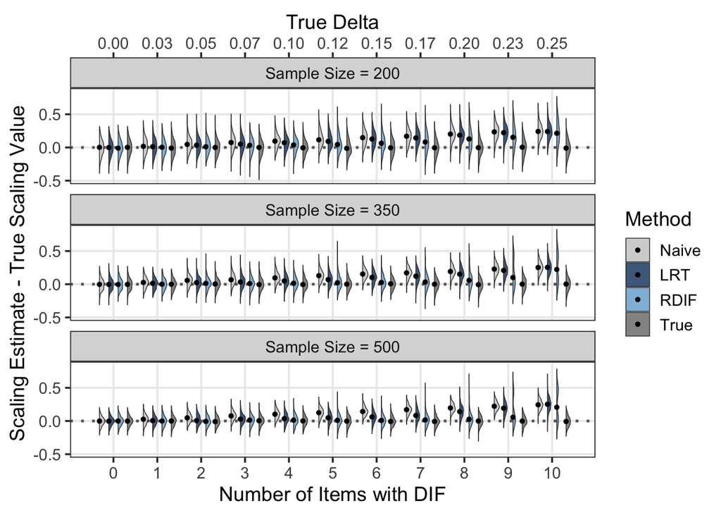

```r
scale_bias <- bind_rows(
  sim_delta |>
    filter(method == "RDIF") |>
    transmute(
      Method = "Naive",
      n_persons,
      n_dif,
      Bias = naive_est - delta_0),
  sim_delta |>
    transmute(
      Method = as.character(method),
      n_persons,
      n_dif,
      Bias = scale_est - delta_0)) |>
  mutate(
    Method = factor(
      Method,
      levels = c("Naive", method_levels),
      ordered = TRUE))

scale_cols <- c("Naive" = "grey80", method_cols)

ggplot(scale_bias, aes(x = n_dif, y = Bias, fill = Method)) +
  geom_hline(yintercept = 0, linetype = 3, linewidth = 0.9, color = "grey40") +
  see::geom_violinhalf(
    aes(group = interaction(n_dif, Method)),
    position = position_dodge(width = 0.85),
    trim = TRUE,
    width = 2,
    linewidth = 0.25,
    alpha = 0.85) +
  stat_summary(
    aes(group = interaction(n_dif, Method)),
    fun = median,
    geom = "point",
    position = position_dodge(width = 0.85),
    size = 0.9,
    color = "black") +
  scale_x_continuous(
    breaks = 0:10,
    sec.axis = sec_axis(
      ~ . * 0.5 / 20,
      breaks = (0:10) * 0.5 / 20,
      labels = sprintf("%.2f", (0:10) * 0.5 / 20),
      name = "True Delta")) +
  scale_fill_manual(values = scale_cols) +
  facet_wrap(
    ~ n_persons,
    nrow = 3,
    scales = "free_y",
    labeller = labeller(n_persons = function(x) paste0("Sample Size = ", x))) +
  labs(
    x = "Number of Items with DIF",
    y = "Scaling Estimate - True Scaling Value",
    fill = "Method") +
  theme(panel.grid.minor = element_blank())
```

```r
scale_bias_table <- scale_bias |>
  summarize(
    bias = mean(Bias, na.rm = TRUE),
    .by = c(Method, n_persons, n_dif)) |>
  mutate(Method = as.character(Method)) |>
  arrange(n_persons, n_dif, Method) |>
  pivot_wider(names_from = Method, values_from = bias)

knitr::kable(scale_bias_table, digits = 3)
```

| n_persons | n_dif | LRT | Naive | RDIF | True |
| --- | --- | --- | --- | --- | --- |
| 200 | 0 | -0.007 | -0.006 | -0.007 | -0.006 |
| 200 | 1 | 0.013 | 0.021 | 0.001 | -0.005 |
| 200 | 2 | 0.035 | 0.049 | 0.016 | -0.001 |
| 200 | 3 | 0.050 | 0.071 | 0.027 | -0.005 |
| 200 | 4 | 0.072 | 0.097 | 0.034 | -0.003 |
| 200 | 5 | 0.100 | 0.122 | 0.054 | -0.001 |
| 200 | 6 | 0.123 | 0.147 | 0.071 | -0.002 |
| 200 | 7 | 0.147 | 0.167 | 0.089 | -0.007 |
| 200 | 8 | 0.189 | 0.202 | 0.137 | 0.000 |
| 200 | 9 | 0.219 | 0.230 | 0.171 | 0.001 |
| 200 | 10 | 0.245 | 0.242 | 0.223 | -0.005 |
| 350 | 0 | -0.002 | -0.003 | -0.001 | -0.003 |
| 350 | 1 | 0.010 | 0.024 | 0.002 | -0.002 |
| 350 | 2 | 0.027 | 0.053 | 0.012 | 0.003 |
| 350 | 3 | 0.036 | 0.076 | 0.014 | 0.001 |
| 350 | 4 | 0.051 | 0.101 | 0.017 | 0.000 |
| 350 | 5 | 0.072 | 0.129 | 0.030 | 0.003 |
| 350 | 6 | 0.099 | 0.155 | 0.037 | 0.005 |
| 350 | 7 | 0.117 | 0.171 | 0.042 | -0.005 |
| 350 | 8 | 0.150 | 0.193 | 0.077 | -0.009 |
| 350 | 9 | 0.209 | 0.228 | 0.160 | 0.002 |
| 350 | 10 | 0.255 | 0.252 | 0.238 | -0.002 |
| 500 | 0 | -0.002 | -0.002 | -0.001 | -0.002 |
| 500 | 1 | 0.006 | 0.023 | -0.001 | -0.002 |
| 500 | 2 | 0.013 | 0.046 | -0.003 | -0.004 |
| 500 | 3 | 0.028 | 0.079 | 0.010 | 0.005 |
| 500 | 4 | 0.038 | 0.102 | 0.014 | 0.003 |
| 500 | 5 | 0.046 | 0.123 | 0.011 | -0.001 |
| 500 | 6 | 0.063 | 0.148 | 0.016 | -0.001 |
| 500 | 7 | 0.087 | 0.171 | 0.025 | -0.004 |
| 500 | 8 | 0.137 | 0.201 | 0.049 | 0.002 |
| 500 | 9 | 0.193 | 0.225 | 0.132 | 0.000 |
| 500 | 10 | 0.251 | 0.248 | 0.240 | -0.005 |

## DTF Effect Bias

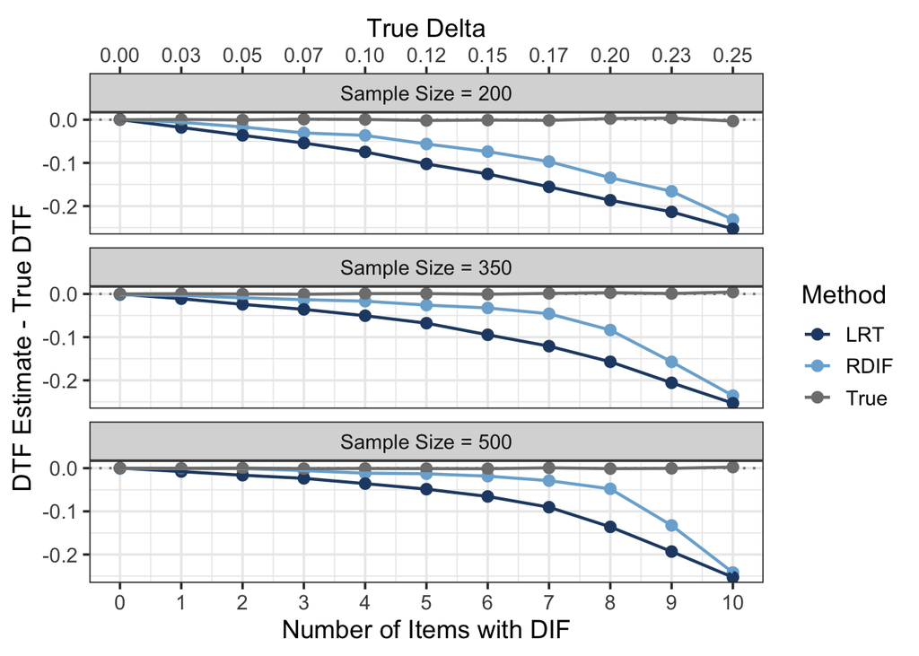

```r
delta_bias <- sim_delta |>
  mutate(Bias = delta_hat - true_Delta) |>
  summarize(
    bias = mean(Bias, na.rm = TRUE),
    .by = c(method, n_persons, n_dif))

ggplot(delta_bias, aes(x = n_dif, y = bias, color = method, group = method)) +
  geom_hline(yintercept = 0, linetype = 3, color = "grey50") +
  geom_point(size = 2.4) +
  geom_line(linewidth = 0.8) +
  scale_x_continuous(
    breaks = 0:10,
    sec.axis = sec_axis(
      ~ . * 0.5 / 20,
      breaks = (0:10) * 0.5 / 20,
      labels = sprintf("%.2f", (0:10) * 0.5 / 20),
      name = "True Delta")) +
  scale_color_manual(values = method_cols) +
  facet_wrap(
    ~ n_persons,
    nrow = 3,
    labeller = labeller(n_persons = function(x) paste0("Sample Size = ", x))) +
  labs(
    x = "Number of Items with DIF",
    y = "DTF Estimate - True DTF",
    color = "Method")
```

```r
delta_bias_wide <- delta_bias |>
  mutate(method = as.character(method)) |>
  arrange(n_persons, n_dif, method) |>
  select(method, n_persons, n_dif, bias) |>
  pivot_wider(names_from = method, values_from = bias)

knitr::kable(delta_bias_wide, digits = 3)
```

| n_persons | n_dif | LRT | RDIF | True |
| --- | --- | --- | --- | --- |
| 200 | 0 | 0.000 | 0.001 | 0.000 |
| 200 | 1 | -0.018 | -0.006 | 0.001 |
| 200 | 2 | -0.036 | -0.017 | 0.000 |
| 200 | 3 | -0.054 | -0.031 | 0.001 |
| 200 | 4 | -0.075 | -0.036 | 0.001 |
| 200 | 5 | -0.102 | -0.056 | -0.002 |
| 200 | 6 | -0.126 | -0.074 | -0.001 |
| 200 | 7 | -0.155 | -0.097 | -0.002 |
| 200 | 8 | -0.186 | -0.134 | 0.003 |
| 200 | 9 | -0.213 | -0.166 | 0.004 |
| 200 | 10 | -0.253 | -0.231 | -0.003 |
| 350 | 0 | 0.000 | -0.002 | 0.000 |
| 350 | 1 | -0.011 | -0.004 | 0.001 |
| 350 | 2 | -0.024 | -0.009 | 0.000 |
| 350 | 3 | -0.036 | -0.013 | -0.001 |
| 350 | 4 | -0.050 | -0.017 | 0.001 |
| 350 | 5 | -0.068 | -0.026 | 0.001 |
| 350 | 6 | -0.095 | -0.032 | -0.001 |
| 350 | 7 | -0.121 | -0.046 | 0.001 |
| 350 | 8 | -0.157 | -0.084 | 0.003 |
| 350 | 9 | -0.206 | -0.157 | 0.001 |
| 350 | 10 | -0.253 | -0.236 | 0.004 |
| 500 | 0 | 0.000 | -0.001 | 0.000 |
| 500 | 1 | -0.008 | -0.001 | 0.000 |
| 500 | 2 | -0.016 | -0.001 | 0.000 |
| 500 | 3 | -0.024 | -0.006 | -0.001 |
| 500 | 4 | -0.036 | -0.012 | -0.001 |
| 500 | 5 | -0.049 | -0.013 | -0.001 |
| 500 | 6 | -0.066 | -0.018 | -0.001 |
| 500 | 7 | -0.090 | -0.029 | 0.001 |
| 500 | 8 | -0.136 | -0.048 | -0.001 |
| 500 | 9 | -0.193 | -0.133 | 0.000 |
| 500 | 10 | -0.253 | -0.242 | 0.003 |

# Rejection Rates

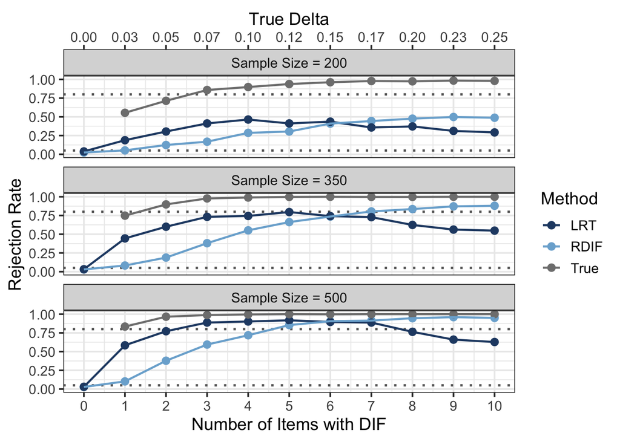

```r
sim_power <- sim_delta |>
  summarize(
    rejection_rate = mean(rejected, na.rm = TRUE),
    .by = c(method, n_persons, n_dif)) |>
  mutate(
    rejection_rate = ifelse(
      method == "True" & n_dif == 0,
      NA_real_,
      rejection_rate))

ggplot(sim_power, aes(x = n_dif, y = rejection_rate, color = method, group = method)) +
  geom_hline(yintercept = 0.05, linetype = 3, linewidth = 0.9, color = "grey40") +
  geom_hline(yintercept = 0.80, linetype = 3, linewidth = 0.9, color = "grey40") +
  geom_point(size = 2.4, na.rm = TRUE) +
  geom_line(linewidth = 0.8, na.rm = TRUE) +
  scale_x_continuous(
    breaks = 0:10,
    sec.axis = sec_axis(
      ~ . * 0.5 / 20,
      breaks = (0:10) * 0.5 / 20,
      labels = sprintf("%.2f", (0:10) * 0.5 / 20),
      name = "True Delta")) +
  scale_y_continuous(limits = c(0, 1), breaks = seq(0, 1, .25)) +
  scale_color_manual(values = method_cols) +
  facet_wrap(
    ~ n_persons,
    nrow = 3,
    labeller = labeller(n_persons = function(x) paste0("Sample Size = ", x))) +
  labs(
    x = "Number of Items with DIF",
    y = "Rejection Rate",
    color = "Method")
```

```r
sim_power_wide <- sim_power |>
  pivot_wider(names_from = method, values_from = rejection_rate)

knitr::kable(sim_power_wide, digits = 3)
```

| n_persons | n_dif | RDIF | LRT | True |
| --- | --- | --- | --- | --- |
| 200 | 0 | 0.024 | 0.038 | NA |
| 200 | 1 | 0.052 | 0.188 | 0.554 |
| 200 | 2 | 0.124 | 0.304 | 0.714 |
| 200 | 3 | 0.168 | 0.412 | 0.858 |
| 200 | 4 | 0.286 | 0.464 | 0.898 |
| 200 | 5 | 0.304 | 0.412 | 0.938 |
| 200 | 6 | 0.410 | 0.436 | 0.962 |
| 200 | 7 | 0.444 | 0.358 | 0.978 |
| 200 | 8 | 0.476 | 0.372 | 0.974 |
| 200 | 9 | 0.498 | 0.312 | 0.984 |
| 200 | 10 | 0.488 | 0.292 | 0.980 |
| 350 | 0 | 0.030 | 0.032 | NA |
| 350 | 1 | 0.082 | 0.444 | 0.748 |
| 350 | 2 | 0.188 | 0.600 | 0.898 |
| 350 | 3 | 0.380 | 0.732 | 0.978 |
| 350 | 4 | 0.552 | 0.744 | 0.990 |
| 350 | 5 | 0.662 | 0.796 | 0.998 |
| 350 | 6 | 0.736 | 0.742 | 1.000 |
| 350 | 7 | 0.804 | 0.728 | 0.998 |
| 350 | 8 | 0.836 | 0.624 | 0.998 |
| 350 | 9 | 0.872 | 0.562 | 1.000 |
| 350 | 10 | 0.880 | 0.548 | 1.000 |
| 500 | 0 | 0.028 | 0.030 | NA |
| 500 | 1 | 0.102 | 0.584 | 0.834 |
| 500 | 2 | 0.378 | 0.772 | 0.966 |
| 500 | 3 | 0.594 | 0.888 | 0.988 |
| 500 | 4 | 0.718 | 0.902 | 0.996 |
| 500 | 5 | 0.854 | 0.918 | 1.000 |
| 500 | 6 | 0.906 | 0.896 | 0.998 |
| 500 | 7 | 0.914 | 0.888 | 1.000 |
| 500 | 8 | 0.946 | 0.764 | 1.000 |
| 500 | 9 | 0.960 | 0.660 | 1.000 |
| 500 | 10 | 0.950 | 0.628 | 1.000 |

# Coverage

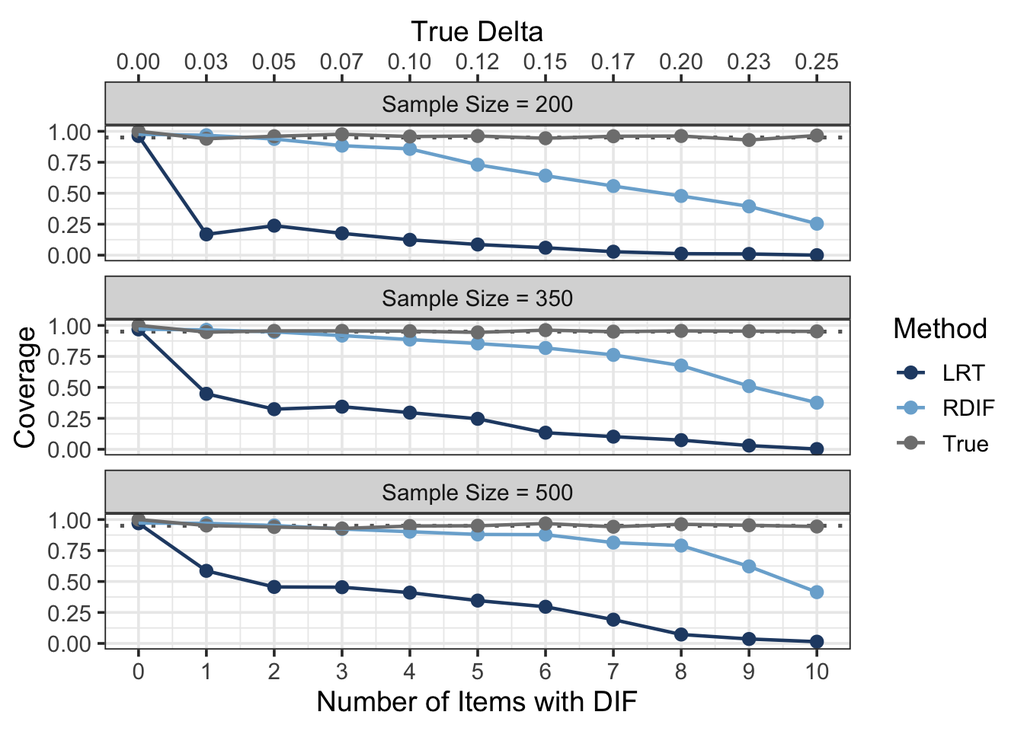

```r
sim_coverage <- sim_delta |>
  summarize(
    coverage = mean(covered, na.rm = TRUE),
    mean_width = mean(2 * qnorm(.975) * delta_se, na.rm = TRUE),
    mean_se = mean(delta_se, na.rm = TRUE),
    .by = c(method, n_persons, n_dif))

ggplot(sim_coverage, aes(x = n_dif, y = coverage, color = method, group = method)) +
  geom_hline(yintercept = 0.95, linetype = 3, linewidth = 0.9, color = "grey40") +
  geom_point(size = 2.4) +
  geom_line(linewidth = 0.8) +
  scale_x_continuous(
    breaks = 0:10,
    sec.axis = sec_axis(
      ~ . * 0.5 / 20,
      breaks = (0:10) * 0.5 / 20,
      labels = sprintf("%.2f", (0:10) * 0.5 / 20),
      name = "True Delta")) +
  scale_y_continuous(limits = c(0, 1), breaks = seq(0, 1, .25)) +
  scale_color_manual(values = method_cols) +
  facet_wrap(
    ~ n_persons,
    nrow = 3,
    labeller = labeller(n_persons = function(x) paste0("Sample Size = ", x))) +
  labs(
    x = "Number of Items with DIF",
    y = "Coverage",
    color = "Method")
```

```r
sim_coverage_wide <- sim_coverage |>
  select(method, n_persons, n_dif, coverage) |>
  pivot_wider(names_from = method, values_from = coverage)

knitr::kable(sim_coverage_wide, digits = 3)
```

| n_persons | n_dif | RDIF | LRT | True |
| --- | --- | --- | --- | --- |
| 200 | 0 | 0.976 | 0.962 | 1.000 |
| 200 | 1 | 0.968 | 0.168 | 0.940 |
| 200 | 2 | 0.938 | 0.238 | 0.960 |
| 200 | 3 | 0.884 | 0.176 | 0.976 |
| 200 | 4 | 0.858 | 0.124 | 0.958 |
| 200 | 5 | 0.730 | 0.086 | 0.962 |
| 200 | 6 | 0.642 | 0.060 | 0.944 |
| 200 | 7 | 0.558 | 0.028 | 0.960 |
| 200 | 8 | 0.478 | 0.012 | 0.962 |
| 200 | 9 | 0.394 | 0.010 | 0.930 |
| 200 | 10 | 0.254 | 0.000 | 0.966 |
| 350 | 0 | 0.970 | 0.968 | 1.000 |
| 350 | 1 | 0.964 | 0.448 | 0.946 |
| 350 | 2 | 0.948 | 0.324 | 0.956 |
| 350 | 3 | 0.918 | 0.344 | 0.956 |
| 350 | 4 | 0.886 | 0.296 | 0.954 |
| 350 | 5 | 0.854 | 0.246 | 0.944 |
| 350 | 6 | 0.818 | 0.134 | 0.962 |
| 350 | 7 | 0.762 | 0.102 | 0.950 |
| 350 | 8 | 0.676 | 0.074 | 0.956 |
| 350 | 9 | 0.510 | 0.030 | 0.954 |
| 350 | 10 | 0.376 | 0.002 | 0.952 |
| 500 | 0 | 0.972 | 0.970 | 1.000 |
| 500 | 1 | 0.970 | 0.586 | 0.952 |
| 500 | 2 | 0.952 | 0.456 | 0.940 |
| 500 | 3 | 0.924 | 0.454 | 0.928 |
| 500 | 4 | 0.902 | 0.410 | 0.948 |
| 500 | 5 | 0.880 | 0.346 | 0.950 |
| 500 | 6 | 0.878 | 0.296 | 0.968 |
| 500 | 7 | 0.814 | 0.192 | 0.942 |
| 500 | 8 | 0.790 | 0.072 | 0.962 |
| 500 | 9 | 0.622 | 0.036 | 0.954 |
| 500 | 10 | 0.414 | 0.014 | 0.944 |